# League of Legends Ranked Analysis

Perry Tsang

## Introduction to League of Legends Ranking System

In League of Legends, one of the main modes is 5v5 ranked, with players being matched with other players to make teams of 5 to play against other teams in the same server region. There are 2 such ranked systems: solo/duo queue and flex queue. Solo/duo (commonly referred to as just solo queue), as the name suggests, only allows a player to play either by himself or group up with one other person in a similar skill range before being matched with a team. Flex queue on the other hand allows players to play by themselves or group up to create teams of sizes 2, 3, or 5 with other players of a similar skill level before being matched with a team. The focus of this analysis will be on north american (NA) solo queue players.

The ranks are split into 9 tiers; from highest to lowest: Challenger, Grandmaster, Master, Diamond, Platinum, Gold, Silver, Bronze, and Iron. From Diamond down, there is a division system dividing each tier into 4 divisions; from highest to lowest: I, II, III, and IV. Players climb within their own tier and division until they reach division I. If they manage to win at the top of division I, they will move to division IV of the next tier. The exception to this rule is moving from Diamond I to Master and all tiers Master and above. Master, Grandmaster, and Challenger do not have any divisions nor do they use the point system the other tiers use to move up. Instead, they use a time based system that refreshes every day, automatically moving players in and out as their performance changes. It should also be noted that those 3 tiers are designed with a cap that limits the number of players allowed to be in each of them at any time.

## Research question and initial analysis

Because each tier represents a skill level and requires many games to climb the ranked ladder, I want to see the distribution of players, how the number of games played increase as players move towards the top, as well as how their win rates compare. In addition, I want to compare some basic stats of the 3 top tiers and see which role is the most common among those players and compare win rates and games played between roles.

## Front matter

### Clearing environment and loading packages

```r
# Clear environment
rm(list=ls())

# Load packages
library(mosaic)
library(tidyverse)
```

### Loading in all data

```r
# Load ranked data
GoldPlus <- read.csv("goldPlus.csv", header=FALSE, encoding="UTF-8", stringsAsFactors=FALSE)
Silver <- read.csv("silver.csv", header=FALSE, encoding="UTF-8", stringsAsFactors=FALSE)
Bronze <- read.csv("bronze.csv", header=FALSE, encoding="UTF-8", stringsAsFactors=FALSE)
Iron <- read.csv("iron.csv", header=FALSE, encoding="UTF-8", stringsAsFactors=FALSE)

# Load top account IDs
ChallengerIDs <- read.csv("challengerIDs.csv", header=FALSE, encoding="UTF-8", stringsAsFactors=FALSE)
GrandmasterIDs <- read.csv("grandmasterIDs.csv", header=FALSE, encoding="UTF-8", stringsAsFactors=FALSE)
MasterIDs <- read.csv("masterIDs.csv", header=FALSE, encoding="UTF-8", stringsAsFactors=FALSE)

# Load top account recent matches
ChallengerMatches <- read.csv("challengerMatches.csv", header=FALSE, encoding="UTF-8", stringsAsFactors=FALSE)
GrandmasterMatches <- read.csv("grandmasterMatches.csv", header=FALSE, encoding="UTF-8", stringsAsFactors=FALSE)
MasterMatches <- read.csv("masterMatches.csv", header=FALSE, encoding="UTF-8", stringsAsFactors=FALSE)
```

### Assigning variable names

Because the raw data does not have any headers (variable names), they are added here before analysis based on documentation

```r
# All ranked data have the same variables
names(GoldPlus) <- c("summonerID", "tier", "division", "wins", "losses", "veteran")
names(Silver) <- c("summonerID", "tier", "division", "wins", "losses", "veteran")
names(Bronze) <- c("summonerID", "tier", "division", "wins", "losses", "veteran")
names(Iron) <- c("summonerID", "tier", "division", "wins", "losses", "veteran")

# All top account IDs have the same variables
names(ChallengerIDs) <- c("summonerID", "accountID", "level")
names(GrandmasterIDs) <- c("summonerID", "accountID", "level")
names(MasterIDs) <- c("summonerID", "accountID", "level")

# All top account recent games have the same variables
names(ChallengerMatches) <- c("accountID", "role", "lane")
names(GrandmasterMatches) <- c("accountID", "role", "lane")
names(MasterMatches) <- c("accountID", "role", "lane")
```

## Initial analysis of raw data

```r
# Analysis of ranked data
GoldPlus %>% head()
```

|  | summonerID | tier | division | wins | losses | veteran |
| --- | --- | --- | --- | --- | --- | --- |
| 1 | CFOhmk3QWt7IIaWSBLkY0wFac4yUFEAfF1W0GzFYTNfLr2s | CHALLENGER | I | 402 | 265 | TRUE |
| 2 | wQQ4GLNOi0JC5j0vLIHsLKoUivnEcc4h5RDPap_nv4t2kzE | CHALLENGER | I | 267 | 180 | TRUE |
| 3 | ai2oXjw4wVxhyGafhKgVFd8hvYFGGf3t4UdMayD--nHFRpA | CHALLENGER | I | 951 | 835 | TRUE |
| 4 | EMo2uqijjDYMvkO8rFJhsnCRFHcGD2Dz7yndxA0mYIn5fy0 | CHALLENGER | I | 405 | 256 | TRUE |
| 5 | zi8izvBtkSBJ8XcWOFnzxuip23rYqfGeE1eUsH4RdUVDCwM | CHALLENGER | I | 747 | 644 | TRUE |
| 6 | pxLMfkhtZiMO6jlpP1fw_17LR3RAgW1LsLn-CwxoHsoyLfI | CHALLENGER | I | 826 | 699 | TRUE |

```r
Silver %>% head()
```

|  | summonerID | tier | division | wins | losses | veteran |
| --- | --- | --- | --- | --- | --- | --- |
| 1 | cHRXfeKUKqusBYcFO-94rD5JrID0IdXFr7Az3anxwpp1JVt1 | SILVER | I | 104 | 110 | TRUE |
| 2 | hPUziOzAY9ayRluBTycPuAnGVcor0ZnIefTv4O0ycXfIs0uo | SILVER | I | 52 | 42 | FALSE |
| 3 | bxxDyBGJ3EX1DMo3IGoT5oMPwLxOIVeiepaYShfqIGEuxOvc | SILVER | I | 60 | 55 | FALSE |
| 4 | HJ_afNpM-iPbyb21g0-RRAlqfgpuyqrYG94aoU_avMPpzZQv | SILVER | I | 16 | 14 | FALSE |
| 5 | 8FLqYk37mH13tdiBV3tHTfCxAPiNJHaB3C1m2OC2mDw0DOnv | SILVER | I | 28 | 25 | FALSE |
| 6 | rqKOGBZV0KFXYHiCPpmoWqIJ4-jhD7hwvaGizdGy9zOOcqFG | SILVER | I | 10 | 7 | FALSE |

```r
Bronze %>% head()
```

|  | summonerID | tier | division | wins | losses | veteran |
| --- | --- | --- | --- | --- | --- | --- |
| 1 | 3pSaUqVKk7HrvVPFPMB5eXhamzroYyiNvsowIgCzgLlfPbuU | BRONZE | I | 15 | 24 | False |
| 2 | YUcVCwnM4LcgCdNdSDhMNYZPF5jyty0KMF9QVObizke9P0Ye | BRONZE | I | 11 | 27 | False |
| 3 | tfx8eOtoQzBMKkvQIIc4DDiHNfhwYIX0dmZMkPH2mq_ihBwW | BRONZE | I | 12 | 26 | False |
| 4 | wGvgMREII1mZ6pB18-HtaKvGOh8UyXBMum37-OMdn5VcE9_e | BRONZE | I | 9 | 6 | False |
| 5 | sBWg2yl5g-Dd4t50-zjDe1YMuVt_QqKgnJ02T1lPb2dPfEaL | BRONZE | I | 9 | 20 | False |
| 6 | Vf9uAeOd1dmvsJ0M89_06mrBkM3-Jdv2i_XKrlCrenoEk3xe | BRONZE | I | 16 | 27 | False |

```r
Iron %>% head()
```

|  | summonerID | tier | division | wins | losses | veteran |
| --- | --- | --- | --- | --- | --- | --- |
| 1 | kSQwkS2iyyW0IN4B4S6s2Rr5AsLT4-OSzgoXDfP4eELU9Sq3 | IRON | I | 2 | 14 | False |
| 2 | SmgTCJw88jqp3x_8Wrm0vTiCkrZb-UVrOXr28yhJCL30BWUT | IRON | I | 52 | 100 | False |
| 3 | 63WMXnfXLEFNAhEKVSbrHriJ0flowsWxJVI-H9e3uuQ2SkAc | IRON | I | 12 | 21 | False |
| 4 | qd8RsACbR3DrcIVLP7hdFred3XVawqDJkaEnc6RKNz80bmjX | IRON | I | 13 | 35 | False |
| 5 | qUP0m8MtQAFx-0dyomn0ybofs_lm6tYt0vqlrqD7L8DYRlXa | IRON | I | 14 | 24 | False |
| 6 | RyZS5P95XAE-ChcERwTFnEvr4xo9r45zi0PFFkBxN2PcLhXf | IRON | I | 21 | 50 | False |

In these 4 datasets, each case represents a player, with an internal summonerID, their tier, division, wins, losses, and veteran status, TRUE if they have been in that tier for 100 games or more.

```r
ChallengerIDs %>% head()
```

|  | summonerID | accountID | level |
| --- | --- | --- | --- |
| 1 | CFOhmk3QWt7IIaWSBLkY0wFac4yUFEAfF1W0GzFYTNfLr2s | QguRkGMis44bJz1V_HfDI6aRHDYnDEeq8rxP2_44ddeYVAk | 118 |
| 2 | wQQ4GLNOi0JC5j0vLIHsLKoUivnEcc4h5RDPap_nv4t2kzE | bv_0PG4AUPc5J_5FQGputiLWCZ-zaVCRQC-CxpSSbvegJQ | 162 |
| 3 | ai2oXjw4wVxhyGafhKgVFd8hvYFGGf3t4UdMayD--nHFRpA | 3szKWV80WxhapS0fSvNCCfRA_lsffWQ0D1zJrMfeeGRyag | 278 |
| 4 | EMo2uqijjDYMvkO8rFJhsnCRFHcGD2Dz7yndxA0mYIn5fy0 | 7nqBk12UX8S8SzrT-wZUbhBwNaI7swekp1kQC8yfK6OgtA | 205 |
| 5 | zi8izvBtkSBJ8XcWOFnzxuip23rYqfGeE1eUsH4RdUVDCwM | F0yzGlsCSguatr6nk_j9mYgwZMvLm7SgAQlWYY6HMBJxl9A | 270 |
| 6 | pxLMfkhtZiMO6jlpP1fw_17LR3RAgW1LsLn-CwxoHsoyLfI | lvNt0Lg1l9knQ8bpzt5VWHUfqUdH-XwB_TJU3IteV5uXtt8 | 217 |

```r
GrandmasterIDs %>% head()
```

|  | summonerID | accountID | level |
| --- | --- | --- | --- |
| 1 | ZRjlEowP8SsCeJv1d1TGf6rzYVqquYpnM8IdR-JEcvhLPwY | Yp-izHCG4-I7-jJU4uH8JLpFSlO80VqeK4Az2gZSYe-Dakk | 172 |
| 2 | ZfXKSy3kq8nC8TfC8K4CDZSeUoB3B_K5GIvQXborW-riYJRm | vS2MN0gVMImQmEl86nJOI_NVUpowbFbS1OCfZXYH2pSkz2p8R3gJg9Vq | 53 |
| 3 | xNl_hrxdL4fCx3SsLRxdABsmKdJ_YbA2sALZI1aHTA8CIg8 | MEbBXPSwl7E_PNeIRdiNVIPAx6gm_v4MbHV6SivZ9bdRPg | 128 |
| 4 | zYYDOiljF_G8p9PFm_MJPsRreFulrPuQUwOIwMB1PwdG0R9w | u9N_nmk8ju3oHcacbx_AQ4vks83D4q2Wg6yfjxVep-2-N_Re-t-83W9_ | 65 |
| 5 | QCFZ-LXWyvzIf9VyVtqXekwDcZhbCHy4gH95BTRLaqhy8nk | cNqYWM-Zy4bTevTj6JEGag9l7xd1ZmRBjKMwFHoOlVI_b1k | 86 |
| 6 | qZyAP9YnHe8Ef8GMSyTsH7qqwm20Ej8K7lLdZatbHS3IsnE | -ihB02Sme8dFmaGvpTWpKyxRLR6WwhQMcabGLHrqxFpyJw | 303 |

```r
MasterIDs %>% head()
```

|  | summonerID | accountID | level |
| --- | --- | --- | --- |
| 1 | 69nO9NNiJlKCzr6nDD9G09F6elaBZYFxHdhpiaTz4VrBaLM | HbRwAKeTyOoGkWjRYwDNEQSgLYMvueTWbjr8hVF6iSGhXQ | 141 |
| 2 | xTg4kYzQXiEyPPcNOjBvGUKVTWmlxIWkpoXUK8SgnaYf8gE | jo0J35MhRyYoWbPjKXcrtZkkqsutzaZNvT8t5DAf95EiMA | 112 |
| 3 | tLz3ZCZJor2kOIZkmExlokGJSl6MJ03GY_V_oyO8EaKdrKA | T4NcFI-joW55M_u8JY13wh_pfEqiuarOeqjFzwUpLNKflq8 | 120 |
| 4 | indSF9yLpk_odZ2XMf9l1CCVtLlMvXS27DVZ32VhiYrOI6s | jSkckDqLdvq1UvQc0mHKl_jY7yjhpxZgQtXDsSW7RN6sBQ | 131 |
| 5 | vTGhgdvZJDvrRsDqOVURk5b3vZQyylnuxQOgyApzWua2W5o | TSAM0fJBXpgEgwdJAuRaE8i28xg-gfXfpiyK2JAdEvhmiA | 219 |
| 6 | sceGx6Fws6QArcJzqeu-dLSCq89Hqtw_zKE0EQ1nr5Kbe1g_ | STNesAmIH-PnD2d3LV2vg-irqgr8m2Zu9ztf-6AWMtbPAiK7ZyokpDFt | 42 |

In these 3 datasets, each case is a player having an internal summonerID, accountID, and account level.

```r
ChallengerMatches %>% head()
```

|  | accountID | role | lane |
| --- | --- | --- | --- |
| 1 | QguRkGMis44bJz1V_HfDI6aRHDYnDEeq8rxP2_44ddeYVAk | DUO_SUPPORT | NONE |
| 2 | QguRkGMis44bJz1V_HfDI6aRHDYnDEeq8rxP2_44ddeYVAk | DUO_SUPPORT | BOTTOM |
| 3 | QguRkGMis44bJz1V_HfDI6aRHDYnDEeq8rxP2_44ddeYVAk | DUO_SUPPORT | NONE |
| 4 | QguRkGMis44bJz1V_HfDI6aRHDYnDEeq8rxP2_44ddeYVAk | DUO_SUPPORT | NONE |
| 5 | QguRkGMis44bJz1V_HfDI6aRHDYnDEeq8rxP2_44ddeYVAk | DUO_SUPPORT | BOTTOM |
| 6 | QguRkGMis44bJz1V_HfDI6aRHDYnDEeq8rxP2_44ddeYVAk | NONE | JUNGLE |

```r
GrandmasterMatches %>% head()
```

|  | accountID | role | lane |
| --- | --- | --- | --- |
| 1 | Yp-izHCG4-I7-jJU4uH8JLpFSlO80VqeK4Az2gZSYe-Dakk | DUO_CARRY | BOTTOM |
| 2 | Yp-izHCG4-I7-jJU4uH8JLpFSlO80VqeK4Az2gZSYe-Dakk | DUO_CARRY | BOTTOM |
| 3 | Yp-izHCG4-I7-jJU4uH8JLpFSlO80VqeK4Az2gZSYe-Dakk | DUO_SUPPORT | BOTTOM |
| 4 | Yp-izHCG4-I7-jJU4uH8JLpFSlO80VqeK4Az2gZSYe-Dakk | DUO_SUPPORT | BOTTOM |
| 5 | Yp-izHCG4-I7-jJU4uH8JLpFSlO80VqeK4Az2gZSYe-Dakk | DUO | NONE |
| 6 | Yp-izHCG4-I7-jJU4uH8JLpFSlO80VqeK4Az2gZSYe-Dakk | DUO_CARRY | BOTTOM |

```r
MasterMatches %>% head()
```

|  | accountID | role | lane |
| --- | --- | --- | --- |
| 1 | HbRwAKeTyOoGkWjRYwDNEQSgLYMvueTWbjr8hVF6iSGhXQ | DUO_SUPPORT | BOTTOM |
| 2 | HbRwAKeTyOoGkWjRYwDNEQSgLYMvueTWbjr8hVF6iSGhXQ | DUO_SUPPORT | BOTTOM |
| 3 | HbRwAKeTyOoGkWjRYwDNEQSgLYMvueTWbjr8hVF6iSGhXQ | DUO_SUPPORT | NONE |
| 4 | HbRwAKeTyOoGkWjRYwDNEQSgLYMvueTWbjr8hVF6iSGhXQ | DUO_SUPPORT | BOTTOM |
| 5 | HbRwAKeTyOoGkWjRYwDNEQSgLYMvueTWbjr8hVF6iSGhXQ | DUO_SUPPORT | BOTTOM |
| 6 | HbRwAKeTyOoGkWjRYwDNEQSgLYMvueTWbjr8hVF6iSGhXQ | SOLO | BOTTOM |

In these 3 datasets, each case is a game played with an internal accountID for a certain player and the role and lane played. From the documentation, these are the last 100 or so games played by each player.

Note that, as the dataframe names suggest, the IDs and last matches dataframes only refer to Master tier players and above.

## Combining like datasets and last minute editing

Because a lot of data is split among different files and therefore read in in different dataframes, they should be combined before starting analysis. Some final changes to make analysis easier will also be done here

```r
# Combining like datasets into one
AllRanks <- rbind(GoldPlus, Silver, Bronze, Iron)
AllTopTierIDs <- rbind(ChallengerIDs, GrandmasterIDs, MasterIDs)
AllTopTierMatches <- rbind(ChallengerMatches, GrandmasterMatches, MasterMatches)

# Removing blank entries in AllRanks
AllRanks <-
  AllRanks %>%
  filter(summonerID != "")

# Setting tiers as a factor so sorting will be in order of rank and not alphabetical
tiers <- c("CHALLENGER", "GRANDMASTER", "MASTER", "DIAMOND", "PLATINUM", "GOLD", "SILVER", "BRONZE", "IRON")
AllRanks <-
  AllRanks %>%
  mutate(tier=factor(tier, levels=tiers))
```

## Basic rank distriutions

### Most populated tier and division

```r
AllRanks %>%
  group_by(tier) %>%
  summarise(count=n()) %>%
  arrange(desc(count))
```

| tier | count |
| --- | --- |
| SILVER | 603278 |
| GOLD | 590404 |
| BRONZE | 289589 |
| PLATINUM | 257890 |
| DIAMOND | 59452 |
| IRON | 39910 |
| MASTER | 1075 |
| GRANDMASTER | 700 |
| CHALLENGER | 600 |

```r
AllRanks %>%
  group_by(tier, division) %>%
  summarise(count=n()) %>%
  arrange(desc(count))
```

| tier | division | count |
| --- | --- | --- |
| GOLD | IV | 262377 |
| SILVER | IV | 171529 |
| SILVER | II | 164867 |
| SILVER | I | 141692 |
| PLATINUM | IV | 139758 |
| GOLD | III | 129791 |
| SILVER | III | 125190 |
| BRONZE | I | 120591 |
| GOLD | II | 120282 |
| GOLD | I | 77954 |

[output cut: 17 more lines]

From these two tables, we can see that the *tier* with the most of players is Silver, while the *division* with the most players is Gold IV. It should also not be surprising that the number of players in Master, Grandmaster, and Challenger have the least since they have a cap on players by design.

### Graphic visualizations of rank distribution

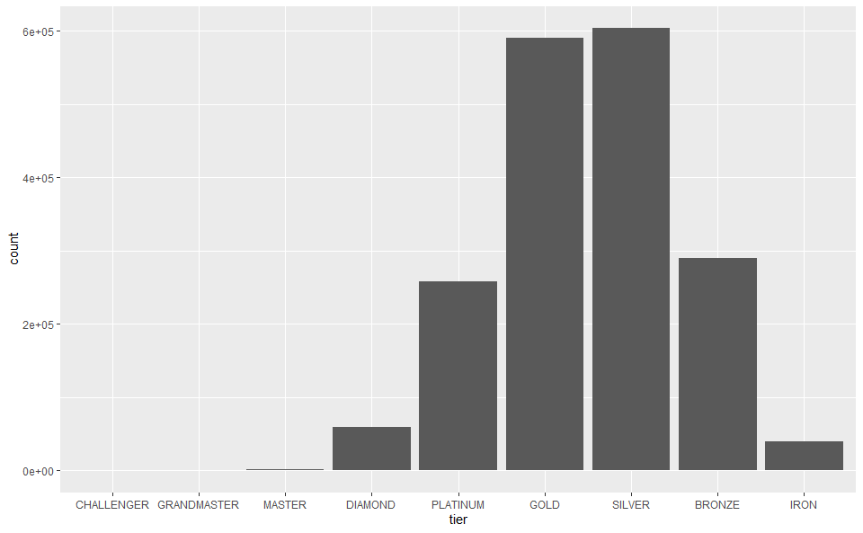

```r
AllRanks %>%
  group_by(tier) %>%
  summarise(count = n()) %>%
  ggplot(aes(x=tier, y=count)) +
  geom_col()
```

From this graph, we can see that the distribution of players is distributed fairly normally with the majority of players being in Gold or Silver. The highest tiers are essentially a rounding error in comparison to the rest of the playerbase.

Ignoring the highest tiers, I want to see how the rest of the rest of the playerbase is distributed when divisions are also taken into account.

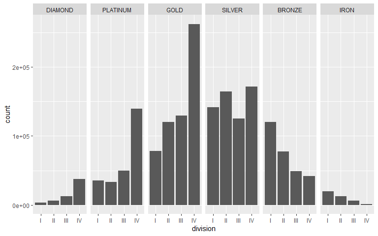

```r
AllRanks %>%
  filter(tier!="CHALLENGER" & tier!="GRANDMASTER" & tier!="MASTER") %>%
  group_by(tier, division) %>%
  summarise(count = n()) %>%
  ggplot(aes(x=division, y=count)) +
  geom_col() +
  facet_wrap(tier~., nrow=1)
```

Given this graph, we can see that Gold IV is by far the most populated division (as confirmed earlier) and that the normal distribution is maintained fairly well, with more players in division IV of Diamond, Platinum, and Gold and division I of Bronze and Iron. The only exception is Silver, with a fairly even distribution of players among its divisions.

## Diving into the game statistics

### Mean games played and win rate

```r
# Calculates total games played and win rate for each player
GameData <-
  AllRanks %>%
  mutate(totalGames=wins+losses, winRate=wins/totalGames) %>%
  select(tier, division, wins, losses, totalGames, winRate)

GameData %>%
  group_by(tier, division) %>%
  summarise(meanGames=mean(totalGames)) %>%
  arrange(desc(meanGames))
```

| tier | division | meanGames |
| --- | --- | --- |
| CHALLENGER | I | 732.96667 |
| GRANDMASTER | I | 669.50429 |
| MASTER | I | 594.92186 |
| DIAMOND | I | 449.92032 |
| DIAMOND | II | 426.81614 |
| DIAMOND | III | 393.10745 |
| DIAMOND | IV | 347.90792 |
| PLATINUM | III | 289.16877 |
| PLATINUM | IV | 286.29975 |
| PLATINUM | II | 253.73148 |

[output cut: 17 more lines]

```r
GameData %>%
  group_by(tier, division) %>%
  summarise(meanWR=mean(winRate)) %>%
  arrange(desc(meanWR))
```

| tier | division | meanWR |
| --- | --- | --- |
| CHALLENGER | I | 0.5568424 |
| DIAMOND | I | 0.5514041 |
| MASTER | I | 0.5460502 |
| PLATINUM | I | 0.5447219 |
| GRANDMASTER | I | 0.5443849 |
| DIAMOND | II | 0.5417153 |
| DIAMOND | III | 0.5353232 |
| PLATINUM | II | 0.5336555 |
| GOLD | I | 0.5319708 |
| DIAMOND | IV | 0.5303775 |

[output cut: 17 more lines]

From this table, we can see that the higher rank a player goes, the more games they play on average, especially in the highest tiers due to the performance based system at that level. The average win rate for each division also generally goes up the higher rank a player goes. This is fairly intuitive as a player must consistently win more games in order to climb up the ranks.

### Plotting games played and win rates

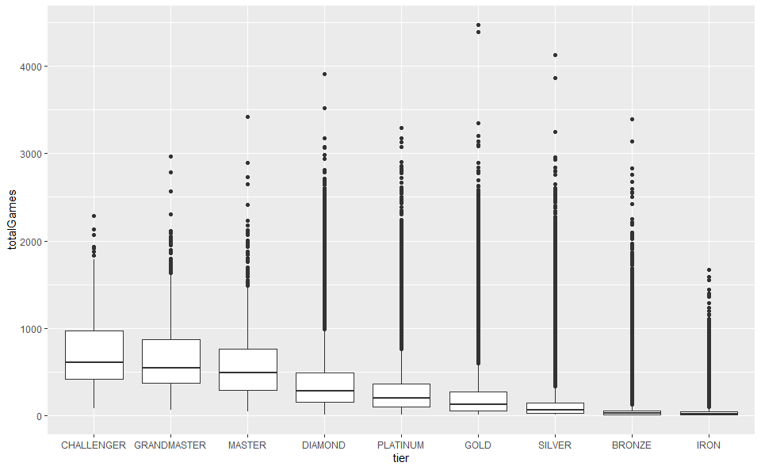

```r
GameData %>%
  ggplot(aes(x=tier, y=totalGames)) +
  geom_boxplot()
```

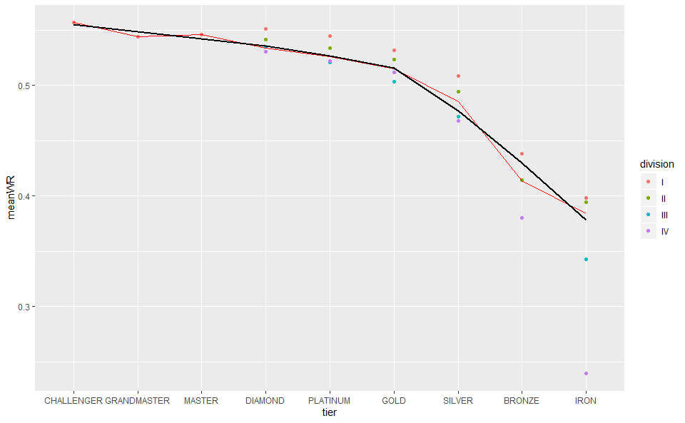

```r
MeanWinRate <-
  GameData %>%
  group_by(tier) %>%
  summarise(meanWR=mean(winRate))

GameData %>%
  group_by(tier, division) %>%
  summarise(meanWR=mean(winRate)) %>%
  ggplot(aes(x=tier, y=meanWR)) +
  geom_point(aes(color=division)) +
  geom_line(data=MeanWinRate, aes(x=tier, y=meanWR, group=1), color="red") +
  geom_smooth(data=MeanWinRate, se=FALSE, aes(x=tier, y=meanWR, group=1), color="black")
```

In this graph, the red line is the win rate of the tier, the black line is a smoother of the tier win rate, and the points are win rates of each division within a tier. In general, a player’s mean win rate increases as they move up tiers. Within a tier, division I has the highest mean win rate with the rest of the mean win rates generally decreasing with division. As tiers Master and above effectively are only one division, the division mean win rate is the mean win rate of the tier.

## Analysis of role

In League of Legends, players pick their primary and secondary position they want to play before queueing to find a game. There are 5 positions: Top, Jungle, Mid, Bottom, and Support. This section will look at positions for Master, Grandmaster, and Challenger tiers since that is the only data available.

### Determining position

The dataframe AllTopTierMatches has the last 100 or so games for each player in the top 3 tiers. However, the raw dataset has two variables describing role: role and lane. Therefore, the position played for each game should be decided first.

```r
# Function that takes role and lane and determines position using simple mapping
determinePosition <- function(role, lane) {
  # These three positions are based on lane
  ifelse(lane == "JUNGLE", "JUNGLE",
  ifelse(lane == "MID", "MID",
  ifelse (lane == "TOP", "TOP",
  # The two bottom lane positions are based on role
  ifelse(role == "DUO_CARRY", "BOTTOM",
  ifelse(role == "DUO_SUPPORT", "SUPPORT", "UNDETERMINED")))))
}

# Updates AllTopTierMatches with just position
TopTierPositions <-
  AllTopTierMatches %>%
  mutate(position = determinePosition(role, lane)) %>%
  select(accountID, position)

TopTierPositions <-
  TopTierPositions %>%
  group_by(accountID, position) %>%
  summarise(games = n())

TopTierPositions
```

| accountID | position | games |
| --- | --- | --- |
| -_ONq6dmdXEoge546d_58lsCBP8Ijf-bR_I-Gg66Qx_aBYX96lvL7_6W | JUNGLE | 8 |
| -_ONq6dmdXEoge546d_58lsCBP8Ijf-bR_I-Gg66Qx_aBYX96lvL7_6W | MID | 13 |
| -_ONq6dmdXEoge546d_58lsCBP8Ijf-bR_I-Gg66Qx_aBYX96lvL7_6W | SUPPORT | 20 |
| -_ONq6dmdXEoge546d_58lsCBP8Ijf-bR_I-Gg66Qx_aBYX96lvL7_6W | TOP | 55 |
| -_ONq6dmdXEoge546d_58lsCBP8Ijf-bR_I-Gg66Qx_aBYX96lvL7_6W | UNDETERMINED | 4 |
| -6o7No8DbQNnA6HkAOaIpflBwfOj1smVLRY_mgjr6XtOOKDuHSe9Gvvh | BOTTOM | 1 |
| -6o7No8DbQNnA6HkAOaIpflBwfOj1smVLRY_mgjr6XtOOKDuHSe9Gvvh | JUNGLE | 79 |
| -6o7No8DbQNnA6HkAOaIpflBwfOj1smVLRY_mgjr6XtOOKDuHSe9Gvvh | SUPPORT | 11 |
| -6o7No8DbQNnA6HkAOaIpflBwfOj1smVLRY_mgjr6XtOOKDuHSe9Gvvh | TOP | 6 |
| -6o7No8DbQNnA6HkAOaIpflBwfOj1smVLRY_mgjr6XtOOKDuHSe9Gvvh | UNDETERMINED | 3 |

[output cut: 990 more lines]

Looking at the new dataset, while the mapping is not perfect as there are some games where position cannot be determined, the vast majority of positions have been sufficiently determined.

### Determining main positions

In general, players will stick to just one position (their “main” position) when climbing the ranks since each position has its own playstyle and it is easier to consistantly improve by sticking to one of them. This chunk will determine a player’s main position.

```r
# Finds main positions
TopTierPositions <-
  TopTierPositions %>%
  filter(position != "UNDETERMINED" & games == max(games))

TopTierPositions
```

| accountID | position | games |
| --- | --- | --- |
| -_ONq6dmdXEoge546d_58lsCBP8Ijf-bR_I-Gg66Qx_aBYX96lvL7_6W | TOP | 55 |
| -6o7No8DbQNnA6HkAOaIpflBwfOj1smVLRY_mgjr6XtOOKDuHSe9Gvvh | JUNGLE | 79 |
| -AKmrdmYWbAkgN2Qlr0f9UA_1egLWLhk6I-42CPb_0rWKr8 | JUNGLE | 154 |
| -aQqwXFLcmgFyFb73ATPrVqPCiGRwS3pElZk4AcT2Xc | SUPPORT | 77 |
| -bbSZrM-6CtGUzo4V-cUYtusetGrITn_014kAF1H9jld8MvvSERX6KCh | SUPPORT | 63 |
| -c8VUCFhYIKepostDwMzVDRLBQfM2EAIPcwAN0vNdqwNefY | BOTTOM | 98 |
| -cOVbhBVoMCqhBAMlz2l4IqJFEwtLVrn94qcYnHuLkU3lw | SUPPORT | 80 |
| -d_Tw-fZF9m3hNlvi6Ar4mf-qYiwtH3FRLLUuF-4nqVuyZE-ZB98jJ5i | BOTTOM | 55 |
| -dQK9EsSatFdMfKbPG8tojWIbg77awAN6fnzcEZ6iu0Y8Y4 | MID | 64 |
| -dv5sZSGHpaDX07anWtJUyb0BVSWScSGZgWpbcI0BBvHApo-jLBqNNak | BOTTOM | 49 |

[output cut: 990 more lines]

### Combining positions and rank

Now that the main positions have been found, they have to be joined with the ranked data table. Internally, there are two IDs for each player, summonerID and accountID. While they refer to the same player, they have different values. Therefore, to join the tables, AllTopTierIDs is used to link summonerID and accountID

```r
# Remove duplicate rows from data
AllTopTierIDs <-
  AllTopTierIDs %>%
  distinct()

# Join the 3 tables
TopRanksPositions <-
  AllRanks %>%
  inner_join(AllTopTierIDs, by="summonerID") %>%
  inner_join(TopTierPositions, by="accountID") %>%
  # Keep only needed variables
  select(tier, wins, losses, position)

TopRanksPositions
```

| tier | wins | losses | position |
| --- | --- | --- | --- |
| CHALLENGER | 402 | 265 | JUNGLE |
| CHALLENGER | 267 | 180 | MID |
| CHALLENGER | 951 | 835 | TOP |
| CHALLENGER | 405 | 256 | BOTTOM |
| CHALLENGER | 747 | 644 | TOP |
| CHALLENGER | 826 | 699 | BOTTOM |
| CHALLENGER | 274 | 218 | MID |
| CHALLENGER | 338 | 249 | SUPPORT |
| CHALLENGER | 392 | 307 | SUPPORT |
| CHALLENGER | 1024 | 888 | JUNGLE |

[output cut: 990 more lines]

Now we can analyze position by rank

### Position distribution by tier

Since Challenger has the lowest number of players of the three tiers and Master the highest number by design, it will be easier to compare role distribution by percentage of players for each position than raw counts.

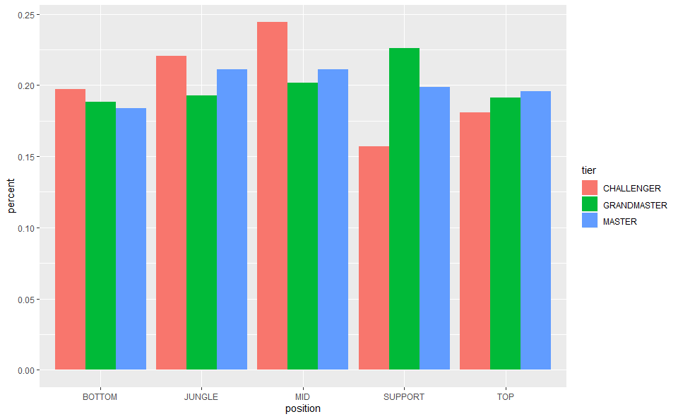

```r
PositionPercent <-
  TopRanksPositions %>%
  group_by(tier, position) %>%
  summarise(count = n()) %>%
  # Spreads so all positions are in one case per tier
  spread(key=position, value=count) %>%
  # Finds percentage of each position for each tier
  mutate(total = sum(BOTTOM, JUNGLE, MID, SUPPORT, TOP),
         BOTTOM = BOTTOM / total,
         JUNGLE = JUNGLE / total,
         MID = MID / total,
         SUPPORT = SUPPORT / total,
         TOP = TOP / total) %>%
  # Gathers positions to original format for ease of using ggplots
  gather(key=position, value=percent, BOTTOM, JUNGLE, MID, SUPPORT, TOP)

PositionPercent %>%
  ggplot(aes(x=position, y=percent)) +
  geom_col(aes(fill=tier), position="dodge")
```

From this graph, we can see that Mid is the most popular role in Challenger, Support is the most popular in Grandmaster, and Jungle and Mid about equally the most popular in Master tier. We can also see that a higher percentage of players in Challenger play Bottom, Jungle, and Mid than in Grandmaster or Master tier but as a result have the lowest percentage of Support and Top players compared to the other tiers. Grandmaster and Master players’ roles are about equally distributed compared to Challenger players, with most roles between 17.5% and 22.5%.

### Total games played across positions

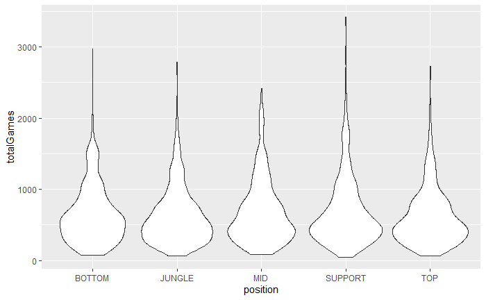

```r
PositionGameData <-
  TopRanksPositions %>%
  mutate(totalGames=wins+losses,
         winRate=wins/totalGames)

PositionGameData %>%
  ggplot(aes(x=position, y=totalGames)) +
  geom_violin()
```

From these violin plots, we can see that most players in Master tier and above will play about 400 to 500 games in each position. The player with the highest number of games played is a support main.

### Win rate across positions

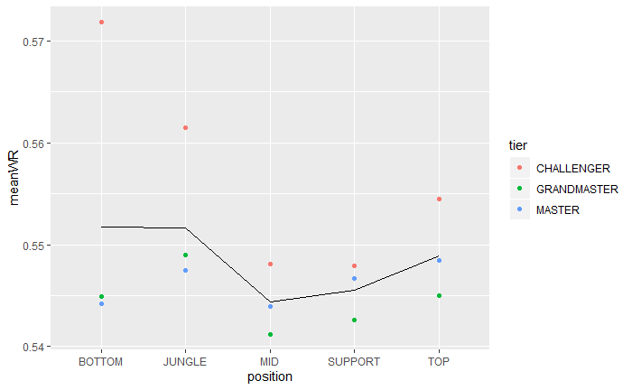

```r
PositionMeanWR <-
  PositionGameData %>%
  group_by(position) %>%
  summarise(meanWR=mean(winRate))

PositionGameData %>%
  group_by(tier, position) %>%
  summarise(meanWR=mean(winRate)) %>%
  ggplot(aes(x=position, y=meanWR)) +
  geom_point(aes(color=tier)) +
  geom_line(data=PositionMeanWR, aes(x=position, y=meanWR, group=1))
```

In this plot, the points are mean win rates colored based on each tier and the line is the mean win rate across all tiers. We can see as a whole, Bottom and Jungle players have the highest mean win rates, with Mid having the lowest. However, looking at win rates across tiers, Challenger players raise the position mean significantly for Bottom and Jungle. We can also see that Challenger players have the highest mean win rates across all positions.